# A Machine Learning Model using Tensorflow to Describe the Market Price of Cryptocurrencies

## The Case of Bitcoin:

[Satoshi Nakamoto](https://en.bitcoin.it/wiki/Satoshi_Nakamoto) is the pseudonym used by the original developer of the first successful implementation of a distributed cryptographic currency operating on a decentralized network of actors who have thus far, committed to using this decentralized ledger as a mechanism of undermining the current paradigm of issuing currency and controlling a society's money supply via a *Central Authority*$^{1}$. Its roots date back to [Wei Dai](http://www.weidai.com) and his description of ["a scheme for a group of untraceable digital pseudonyms to pay each other with money and to enforce contracts amongst themselves without outside help"](http://www.weidai.com/bmoney.txt) which he published on the [CypherPunks](https://en.wikipedia.org/wiki/Cypherpunk) [mailing list](https://lists.cpunks.org/mailman/listinfo/cypherpunks) in 1998$^{2}$.

Bitcoin is a peer-to-peer, **permissionless** payment network that enables the issuance, and the transfer of *electronic cash* between unknown users who rely on public key cryptography to verify the authenticity of the transactions recorded on the public ledger also known as the **blockchain**. The reliance on public key cryptography to feasibly secure a network from attack was demonstrated in the book published by the **RSA Press** in 2001, titled *PKI Implementing & Managing E-Security* in which they argue that *"key lengths are chosen so that it is computationally infeasible to try half the keys within the key space even if you use massive numbers of computers over the length of time the data being protected must remain secure."*$^{3}$ In fact, RSA Laboratories published a bulletin by Robert Silverman in April 2000 in which he compared the relative strengths of various key lengths and algorithms. It would take a typical machine **10E16** years to "crack" a 128 bit Symmetric Key or a 1620 bit RSA key$^{4}$. Bitcoin leverages this strength and the architecture provided by public key cryptography to provide a decentralized solution to security that no longer requires two parties of a transaction to authenticate themselves in order to establish a trust based environment$^{5}$. By eliminating the need for trust, Bitcoin eliminated the on ramps to fraud and abuse by implementing cryptographic mechanisms that simply require a public key to validate a transaction on the network instead of relying on passwords that traditionally provide weak security.

Bitcoin's value comes from its ability to provide society a mechanism in which a central authority is no longer needed to provide a frictionless and immutable transaction on a transparent and secure public ledger. In eliminating the regulated third parties that govern our existing payment networks, transaction fees are reduced and defined by the initiator of a transaction, providing absolute freedom of choice to the consumers in this new digital free market economy by anonymizing the actors involved in a transaction to limit the ability of governments to regulate and legislate the actions of the network's participants. As a distributed network, there is no one central node that can be seized, there is no central authority that controls and regulates the entire network. Any node can be shut down without affecting the pervasiveness of the ledger. So long as the user of the network has access to their cryptographic keys, then the user can access the Bitcoin Ledger and the digital currency accounted for within it.

In the 1990's, cryptographic technology was viewed by the US Government as a national security issue and was considered a [**munitions export**](https://en.wikipedia.org/wiki/Export_of_cryptography) and was regulated as such$^{6}$. This led to the inability of researchers and cryptographers working in the industry to commercialize these tools as products that could help supply the demand and the need for secure methods of communication on an enterprise and eventually, global scale. The regulatory framework forced these individuals, most of whom were senior officials at hi-tech companies, "underground"$^{7}$. Notable individuals involved in the [CypherPunks](https://en.wikipedia.org/wiki/Cypherpunk) movement include [Julian Assange](https://en.wikipedia.org/wiki/Julian_Assange), [Jacob Appelbaum](https://en.wikipedia.org/wiki/Jacob_Appelbaum), [Steven Bellovin](https://en.wikipedia.org/wiki/Steven_M._Bellovin), and [Peter Junger](https://en.wikipedia.org/wiki/Peter_Junger).

As the digital economy has matured, the demand for secure digital enablement tools has grown exponentially$^{8}$. In 1995, [Adam Beck](https://en.wikipedia.org/wiki/Adam_Back) published a cryptographic algorithm based on RSA and suggested that people use it as their email signature to incite **Civil Disobediance**$^{9}$. The freedom sparked by a few lines of code inspired a generation of tools that society could use to help improve the quality of life for humans globally by simply providing access to distributed forms of banking and capital. It was Adam Beck who invented [HashCash](http://www.hashcash.org/) in 1997 as a proof-of-work algorithm that requires computational power from a user's machine to solve a cryptographic puzzle needed to generate a hash stamp that would digitally sign and validate the sending of an email over a network, whose severs used the hash stamp to validate the sender as a legitimate user and sender of email messages on the email platform using a computationally expensive function. It's deployment at first was as an effective counter measure against Distributed-Denial-Of-Service (DDOS) attacks on data networks, and it proved to be of much value as an anti-spam tool to deter would be spammers and DDOS attackers by making it too computationally expensive to proceed with their black-hat objectives.

The goal of an email spammer for example, would be to send 10,000 or more emails per minute via a Broadband connection established under illicit means and false pretenses in order to infiltrate the inboxes of users globally as quickly as possible before their connections are turned off to inundate users with scams, and fraudulent schemes that cost the global economy 20 billion dollars annually and would be approaching over 50 billion dollars if it were not for the private investment in anti-spam technologies such as [HashCach](http://www.hashcash.org/)$^{13}$. In March of 2016, [sixty-two percent](https://www.statista.com/statistics/745017/ransomeware-detected-spam-attachments/) of spam email was some form of RansomWare$^{14}$. In the first quarter of the same year [209 million dollars](https://blog.barkly.com/ransomware-statistics-2016) was paid to criminals conducting RansomWare attacks via spam email infections$^{15}$. Using [HashCash](http://www.hashcash.org/) to validate messages sent over a network would only add a negligible amount of CPU overhead per email sent, resulting in only a slight delay in the regular processing of the message as the CPU performs the calulations necessary to satisfy the proof-of-work algorithm defined by [HashCash](http://www.hashcash.org/). This validation process however, would add an exponential amount of time in providing the computations needed to satisfy the validation of the hashes for the overwhelmingly persistent amount of messages sent by spammers and RansomWare attackers, therefore making it less profitable to attack and conduct a scaleable spamming campaign. This is the same concept used by Bitcoin and its blockchain in order to make the network so computationally expensive to attack, that any attempt would result in a severe financial loss to any would be attackers in terms of the amount of computational hardware that would need to be purchased to compete against all of the nodes coming to consensus across the entire distributed Bitcoin network globally. Bitcoin does differ from [HashCash](http://www.hashcash.org/) in that Bitcoin makes use of the SHA256 algorithm as an added cybersecurity measure. Additionally, HashCash is just the mining function used by the Bitcoin ledger, Bitcoin's innovation and invention had never been fully realized in any previously attempted electronic-cash protocols. [Bitcoin represents a leap forward in electronic cash technology demonstrating for the first time that a respendable, distributed, virtual scarcity based system could be built](http://www.hashcash.org/bitcoin/)$^{16}$.

Bitcoin did not begin in 2009 with [Satoshi Nakamoto](https://en.bitcoin.it/wiki/Satoshi_Nakamoto) and his infamous [whitepaper](https://bitcoin.org/bitcoin.pdf) describing the implementation of the distributed network of computers that could come to consensus on a version of the ledger using a technologically democratic protocol that we know today as [Bitcoin](https://bitcoin.org)$^{10}$. What we know of today as Bitcoin and its OpenSource Blockchain technology that is not governed by exclusionary policy controls and truly lends itself as global currency and democratized payments network, has its foundations in the revolutionary code written by [Adam Beck](http://www.cypherspace.org/adam/) in 1995$^{9}$ below:

```
#!/bin/perl -sp0777i<X+d*lMLa^*lN%0]dsXx++lMlN/dsM0<j]dsj
$/=unpack('H*',$_);$_=`echo 16dio\U$k"SK$/SM$n\EsN0p[lN*1
lK[d2%Sa2/d0$^Ixp"|dc`;s/\W//g;$_=pack('H*',/((..)*)$/)
```

In 2014 it was reported by the World Bank that there were 2 billion people on Earth without access to banking and that 7 countries which include China, Indonesia, India, Pakistan, Nigeria, Bangladesh, and Mexico provide just under half of the world's population of "unbanked" individuals$^{11}$. Amongst the majority of those without access to banking, the data suggests that the poor are overrepresented as people without a banking account. It is a hypothesis of this research, that because of its decentralized and digital nature, **Bitcoin provides an outlet for the poor to participate in the global economy by enabling people in these communities to make transactions on a blockchain without policy constraints, or trade barriers, to allow those in secluded communities to access a larger global economic network using these tools to conduct trade with digital assets**. Those without banking, being overrepresented amongst citizens of developing countries, are now afforded the opportunity to build wealth, and participate in the technological revolution unfolding in the global financial landscape by simply using Bitcoin and its secure approach to money.

The world bank cites the following reasons as to why people in developing countries remain without banking or are considered "unbanked" (97 percent of respondents cited multiple reasons):$^{11}$

1. 30 percent of adults without accounts stated that a banking account is not needed due to insufficient funds (3 percent cited this as the only reason).
2. Banking & transaction costs were cited as a reason for not using banking by 26 percent of respondents.
3. Another 26 percent of respondents declared that they bank through a family member.
4. Distance to a financial institution was cited as a barrier to the use of banking by 22 percent of adults without accounts.
5. Documentation is another intrusive barrier to those without access to banking. 20 percent of the people without access to banking simply do not have the documentation required to use banking as dictated by the Central Powers that control and regulate the global monetary system.
6. Distrust of the global financial system was a reason cited by 16 percent of those without access to banking. Latin America, Europe, and Central Asia have the highest rates of distrust.

#### Stated Need

Addressing the reasons just listed, insufficient funds are due to a lack of opportunity and work. Once educated on the subject, the poor could potentially begin to innovate and create new tools around blockchain technology, which is accessible to the world as an OpenSource library of documented code, in order to develop a locally based ecosystem to support commercial trade in digital currencies. A perfect case study highlighting how digital enablement can help a community adapt to today's technological landscape is Kenya's organic implementaion of the M-PESA as a mobile device based currency. "Few initiatives in microfinance, or for that matter in development, have been as successful as M-PESA: 3 and a half years after launch, over 70 percent of households in Kenya and more importantly over 50 percent of the poor, unbanked and rural populations use the service. M-PESA’s success means there is a real need for small electronic transactions and storage of value."$^{17}$ By providing a "frictionless" mechanism to more easily send and receive "money" between people in a poor community, the M-PESA created a market that provides access to an outlet for entrepreneurial expression, and Kenya has proved that access to a free market with ease of payments between parties to a transaction will infact provide upward financial mobility that takes people out of poverty. "Access to M-PESA increased consumption levels over a six-year period, enabling an estimated 186,000 families, or as many as 2 percent of Kenyan households, to move out of poverty. The impact on female-headed households was more than twice the average measured."$^{18}$

#### Transaction costs

```python
import quandl as ql

# Configure quandl API Key
# & Authenticate
apiKey = "-rLjiPduuzgzKp99MMHb"
ql.ApiConfig.api_key = apiKey

# Capture transaction cost data
cpTxn = ql.get("BCHAIN/CPTRV", start_date='2016-01-03', end_date='2018-06-05', column_index='1')

# Describe data and find mean
cpTxn.describe()
```

|  | Value |
| --- | --- |
| count | 885.000000 |
| mean | 1.086689 |
| std | 0.473484 |
| min | 0.324599 |
| 25% | 0.760000 |
| 50% | 0.975700 |
| 75% | 1.279526 |
| max | 3.755472 |

#### Anonymous Banking, Documentation Requirements, and the Distrust of the Financial System

The innovation that Bitcoin brought to the financial world, was an implentation of a **permissionless** network that approached the problem of **User Authentication** 180 degrees to the opposite of the approach that conventional payment networks currently have in production. Traditional payment networks typically rely on a small network of distributed servers in data centers to provide the network connectivity resources needed to provide the payment services that form the backbone of the global economy. These data centers can be thought of as a central node that can be governed by the policy constraints of a central authority because their distributed architecture was designed for redundancy and to ensure maximum network uptime and continuous connectivity. This architecture that connects to a central node, governed by a central authority, requires the establishment of **trust** amongst all of its users, who are then required to abide by any regulation set forth by the central authority legislating the activities that can be conducted on the network, which in turn will typically and unintentionally, limit access to the network by many of the poorest people in our society, as implied by the WorldBank data presented in this research. This trust based model requires that users be authenticated via permission based mechanisms that typically rely on passwords, device verification methods, biometric data, and other tools that have historically been succeptible to attack, and which continue to provide the on ramp to fraud and abuse of the network. To combat this, policy controls and legislation in the form of documentation requirements, trade embargos, country specific sanctions, and other restrictions are imposed, which unintentionally impact the poorest communities in the developing world.

Bitcoin's approach in implementing a permissionless network that no longer relies on trust, is to instead rely on **Public Key Cryptography**, meaning that anyone with a valid Public/Private Key pair could access the system, and the digital economy created by this new innovation. By relying on the compounding growth in computing power provided by the millions of anonymous actors acting independently, and in their own interests, to build a new digital economy, only serves to exponentially strengthen the security and resiliance of the network. In effect, Satoshi Nakamoto built a system that dares attackers to drain their computing resources in an attempt to attack the system. Attacking the system would in effect, become a "Kamikaze" attack on the network for an attacker and would make no impact on the system as a whole. **The blockchain is immutable**, and is accessible to anyone with an internet connection. This **permissionless** model in effect, provides a practical solution for those who harbor any distrust in a centrally controlled and regulated payments network, it addresses the problem of a lack of documentation in that now, people who live in impoverished communities blockaded by a trade embargo or sanction can access the global digital economy, without having to establish any form of trust to obtain permission to access the economy which can be leveraged to obtain upward financial mobility, and it allows those who want to remain anonymous, to access the digital economy directly instead of through a family member with the use of nothing more than a Public/Private Key pair.

#### Covering the Distance

Humans are a resiliant species indeed. The lengths to which a typical Kenyan would have to go through just less than a decade ago to access the markets and its financial services, *validates the need for more direct approaches to those who need access the most. Distance and the costs associated with travelling throughout vast stretches of Africa, were cited by the World Bank as a barrier to access for the impoverished communities of the world.* "M-PESA has significantly reduced transaction costs in Kenya. When it was launched the average distance to the nearest bank was 9.2 kilometres. Eight years later in 2015 the average distance to the nearest M-PESA agent was a [mere 1.4km](https://www.theigc.org/wp-content/uploads/2016/03/1.-Sarah-Logan.pdf)."$^{20}$ In combination with SpaceX's new Starlink low cost broadband internet service, *the people of the world now have a conduit that provides them access to the digital economy afforeded to them by Bitcoin and other Cryptocurrencies*, and a clear path with access to the tools that have statistically shown us that these approaches can help to eradicate global poverty as one of the United Nation's defined [Sustainable Development Goals](https://www.un.org/sustainabledevelopment/poverty/).

#### How and Where does Bitcoin Derive its Value

The solutions that Bitcoin provides in terms of its security, anonymity, decentralization, predictable issuance of currency of up to 21 million BTC, and in how the technology is implemented in order to provide open access to impoverished communities by addressing the deep seated and systemic infrastructure weaknesses enabled by conventional financial schemes, all seem to provide valid arguments as to why the adoption rates of these cryptographic mechanisms have experienced the exponential growth phenomenon which we have witnessed recently. In order to investigate the reasons why and how Bitcoin derives its value to achieve a goal of this research in describing and predicting its future value, we must first dig deeper into what makes Bitcoin currency, and what makes anything humans use as money, money, and where it derives its inherent value first.

"By 2030, ensure that all men and women, in particular the poor and the vulnerable, have equal rights to economic resources, as well as access to basic services, ownership and control over land and other forms of property, inheritance, natural resources, appropriate new technology and financial services, including microfinance"$^{12}$

"Create sound policy frameworks at the national, regional and international levels, based on pro-poor and gender-sensitive development strategies, to support accelerated investment in poverty eradication actions"$^{12}$

The targets listed above are just two targets defined by the United Nations and Sustainable Development Goals for the eradication of poverty globally to help reduce the amount of people worldwide who subsist on less than two dollars per day.

## Machine Learning

### Featurization

```python
import math
from IPython import display
import numpy as np
import pandas as pd
import seaborn as sb
from sklearn import metrics
import tensorflow as tf
from tensorflow.python.data import Dataset
from matplotlib import cm
from matplotlib import gridspec
from matplotlib import pyplot as plt
from pytrends.request import TrendReq

# Configure verbosity
tf.logging.set_verbosity(tf.logging.ERROR)
```

In the process of converting our data into a series of *indicators*, or vectors of scalar values which are a requirement for the analysis and creation of a model we can use to describe BTC and to test our hypythesis, we will mathematically define what we will accomplish using Python and its associated imports like *TensorFlow*.

Each feature $X$ will provide the placeholder needed to train a model that will allow us to predict the future price of the BTC asset.

We have $X$, $m$ days of data. Each day (each row) has $n$ features. Thus we have:

$$ \left[\begin{array}{cccc} x^{(1)}_{1} & x^{(1)}_{2} & \ldots & x^{(1)}_{n} \\ x^{(2)}_{1} & x^{(2)}_{2} & \ldots & x^{(2)}_{n} \\ & & \vdots \\ x^{(m)}_{1} & x^{(m)}_{2} & \ldots & x^{(m)}_{n} \end{array}\right] \times \left[\begin{array}{c} w_1 \\ w_2 \\ \vdots \\ w_n \end{array}\right] + b = \left[\begin{array}{c} y_1 \\ y_2 \\ \vdots \\ v_n \end{array}\right] $$

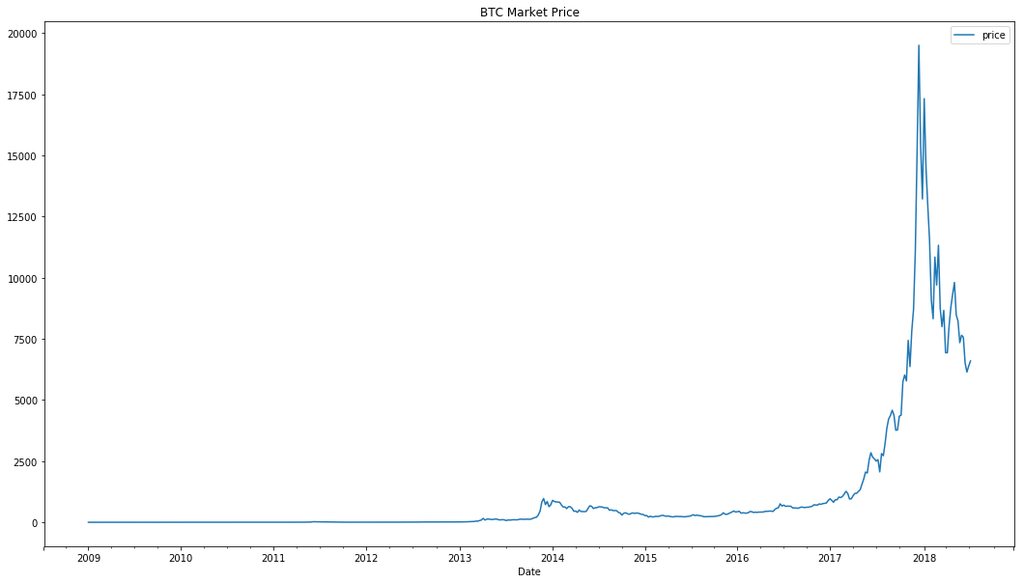

```python
# Capture historical BTC price data
# Data showing the USD market price from Mt.gox
price = ql.get("BCHAIN/MKPRU", collapse="weekly")
price = price.rename(columns={"Value": "price"})

price.plot(title='BTC Market Price', figsize=(18,10))
```

```python
# Display Price Data Type Info
price.info()

# Move Data between past and future to compare Gains vs Losses
price['pshift'] = price.price.shift() # Default periods = 1
price['plag'] = price.price.shift(periods=-1) # Offset periods = -1

# Calculate one period percentage change (xt/xt-1)
price['pchange'] = price.price.div(price.pshift)

price[['price', 'pshift', 'pchange']].tail(5)

# Calculate return
price['return'] = price.pchange.sub(1).mul(100)

price[['price', 'pshift', 'pchange', 'return']].head(100)
# price.to_csv('price.csv')
```

```
<class 'pandas.core.frame.DataFrame'>
DatetimeIndex: 497 entries, 2009-01-04 to 2018-07-08
Data columns (total 1 columns):
price    497 non-null float64
dtypes: float64(1)
memory usage: 7.8 KB
```

| Date | price | pshift | pchange | return |
| --- | --- | --- | --- | --- |
| 2009-01-04 | 0.000000 | NaN | NaN | NaN |
| 2009-01-11 | 0.000000 | 0.000000 | NaN | NaN |
| 2009-01-18 | 0.000000 | 0.000000 | NaN | NaN |
| 2009-01-25 | 0.000000 | 0.000000 | NaN | NaN |
| 2009-02-01 | 0.000000 | 0.000000 | NaN | NaN |
| 2009-02-08 | 0.000000 | 0.000000 | NaN | NaN |
| 2009-02-15 | 0.000000 | 0.000000 | NaN | NaN |
| 2009-02-22 | 0.000000 | 0.000000 | NaN | NaN |
| 2009-03-01 | 0.000000 | 0.000000 | NaN | NaN |
| 2009-03-08 | 0.000000 | 0.000000 | NaN | NaN |
| 2009-03-15 | 0.000000 | 0.000000 | NaN | NaN |
| 2009-03-22 | 0.000000 | 0.000000 | NaN | NaN |
| 2009-03-29 | 0.000000 | 0.000000 | NaN | NaN |
| 2009-04-05 | 0.000000 | 0.000000 | NaN | NaN |
| 2009-04-12 | 0.000000 | 0.000000 | NaN | NaN |
| 2009-04-19 | 0.000000 | 0.000000 | NaN | NaN |
| 2009-04-26 | 0.000000 | 0.000000 | NaN | NaN |
| 2009-05-03 | 0.000000 | 0.000000 | NaN | NaN |
| 2009-05-10 | 0.000000 | 0.000000 | NaN | NaN |
| 2009-05-17 | 0.000000 | 0.000000 | NaN | NaN |
| 2009-05-24 | 0.000000 | 0.000000 | NaN | NaN |
| 2009-05-31 | 0.000000 | 0.000000 | NaN | NaN |
| 2009-06-07 | 0.000000 | 0.000000 | NaN | NaN |
| 2009-06-14 | 0.000000 | 0.000000 | NaN | NaN |
| 2009-06-21 | 0.000000 | 0.000000 | NaN | NaN |
| 2009-06-28 | 0.000000 | 0.000000 | NaN | NaN |
| 2009-07-05 | 0.000000 | 0.000000 | NaN | NaN |
| 2009-07-12 | 0.000000 | 0.000000 | NaN | NaN |
| 2009-07-19 | 0.000000 | 0.000000 | NaN | NaN |
| 2009-07-26 | 0.000000 | 0.000000 | NaN | NaN |
| ... | ... | ... | ... | ... |
| 2010-05-09 | 0.000000 | 0.000000 | NaN | NaN |
| 2010-05-16 | 0.000000 | 0.000000 | NaN | NaN |
| 2010-05-23 | 0.000000 | 0.000000 | NaN | NaN |
| 2010-05-30 | 0.000000 | 0.000000 | NaN | NaN |
| 2010-06-06 | 0.000000 | 0.000000 | NaN | NaN |
| 2010-06-13 | 0.000000 | 0.000000 | NaN | NaN |
| 2010-06-20 | 0.000000 | 0.000000 | NaN | NaN |
| 2010-06-27 | 0.000000 | 0.000000 | NaN | NaN |
| 2010-07-04 | 0.000000 | 0.000000 | NaN | NaN |
| 2010-07-11 | 0.000000 | 0.000000 | NaN | NaN |
| 2010-07-18 | 0.000000 | 0.000000 | NaN | NaN |
| 2010-07-25 | 0.000000 | 0.000000 | NaN | NaN |
| 2010-08-01 | 0.000000 | 0.000000 | NaN | NaN |
| 2010-08-08 | 0.000000 | 0.000000 | NaN | NaN |
| 2010-08-15 | 0.000000 | 0.000000 | NaN | NaN |
| 2010-08-22 | 0.066400 | 0.000000 | inf | inf |
| 2010-08-29 | 0.064800 | 0.066400 | 0.975904 | -2.409639 |
| 2010-09-05 | 0.062900 | 0.064800 | 0.970679 | -2.932099 |
| 2010-09-12 | 0.064999 | 0.062900 | 1.033370 | 3.337043 |
| 2010-09-19 | 0.062599 | 0.064999 | 0.963076 | -3.692364 |
| 2010-09-26 | 0.062279 | 0.062599 | 0.994888 | -0.511190 |
| 2010-10-03 | 0.061400 | 0.062279 | 0.985886 | -1.411391 |
| 2010-10-10 | 0.120000 | 0.061400 | 1.954397 | 95.439739 |
| 2010-10-17 | 0.104500 | 0.120000 | 0.870833 | -12.916667 |
| 2010-10-24 | 0.190000 | 0.104500 | 1.818182 | 81.818182 |
| 2010-10-31 | 0.199000 | 0.190000 | 1.047368 | 4.736842 |
| 2010-11-07 | 0.499999 | 0.199000 | 2.512558 | 151.255779 |
| 2010-11-14 | 0.299000 | 0.499999 | 0.598001 | -40.199880 |
| 2010-11-21 | 0.290000 | 0.299000 | 0.969900 | -3.010033 |
| 2010-11-28 | 0.284610 | 0.290000 | 0.981414 | -1.858621 |

100 rows × 4 columns

```python
hprice = price.truncate(before=pd.Timestamp('2010-08-29'), after=pd.Timestamp('2018-06-17'))

# price['return'].truncate(before=pd.Timestamp('2010-08-29'))

# hprice.to_csv('hPrice.csv')
```

[output not shown]

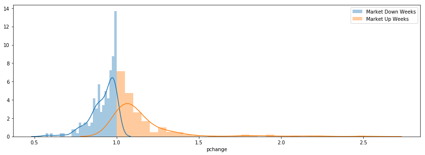

```python
# Distribution Plots
plt.figure(figsize = (15,5))

sb.distplot(hprice['pchange'][hprice['return'] <= 0], bins=30, label = 'Market Down Weeks')

sb.distplot(hprice['pchange'][hprice['return'] >= 0], bins=30, label = 'Market Up Weeks')

plt.legend()
plt.show()
```

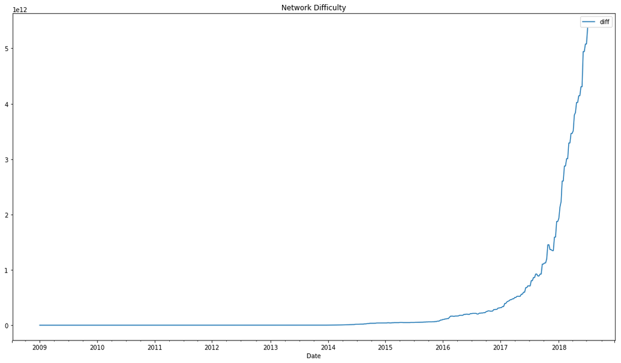

```python
# Bitcoin Difficulty
# Difficulty is a measure of how difficult it is to find a hash below a given target.
diff = ql.get("BCHAIN/DIFF", collapse="weekly")
# diff = diff.rename(columns={"Value": "Network Difficulty"})
diff = diff.rename(columns={"Value": "diff"})

diff.plot(title='Network Difficulty', figsize=(18,10))
```

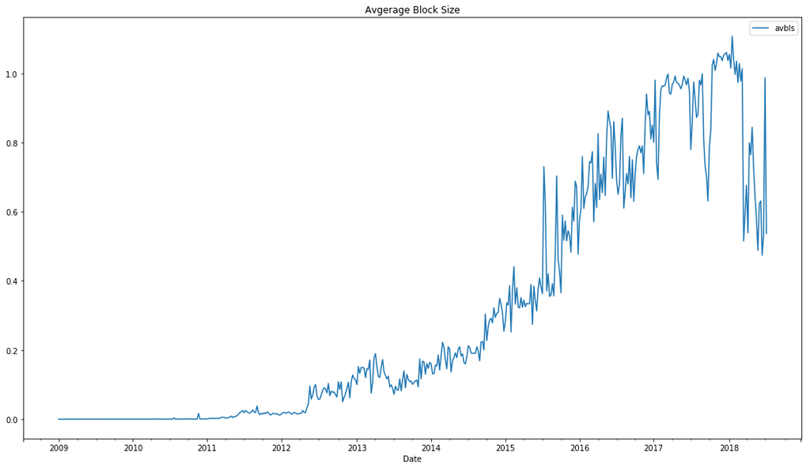

```python
# Bitcoin Average Block Size
# The Average block size in MB
avbls = ql.get("BCHAIN/AVBLS", collapse="weekly")
#avbls = avbls.rename(columns={"Value": "Average Block Size"})
avbls = avbls.rename(columns={"Value": "avbls"})

avbls.plot(title='Avgerage Block Size', figsize=(18,10))
```

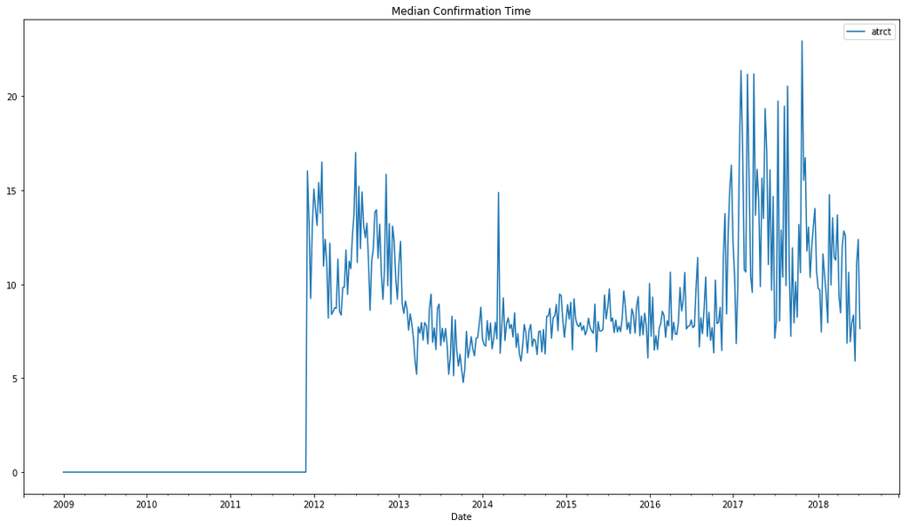

```python
# Bitcoin Median Transaction Confirmation Time
# The Dailiy Median time take for transactions to be accepted into a block.
atrct = ql.get("BCHAIN/ATRCT", collapse="weekly")
# atrct = atrct.rename(columns={"Value": "Median Confirmation Time"})
atrct = atrct.rename(columns={"Value": "atrct"})

atrct.plot(title='Median Confirmation Time', figsize=(18,10))
```

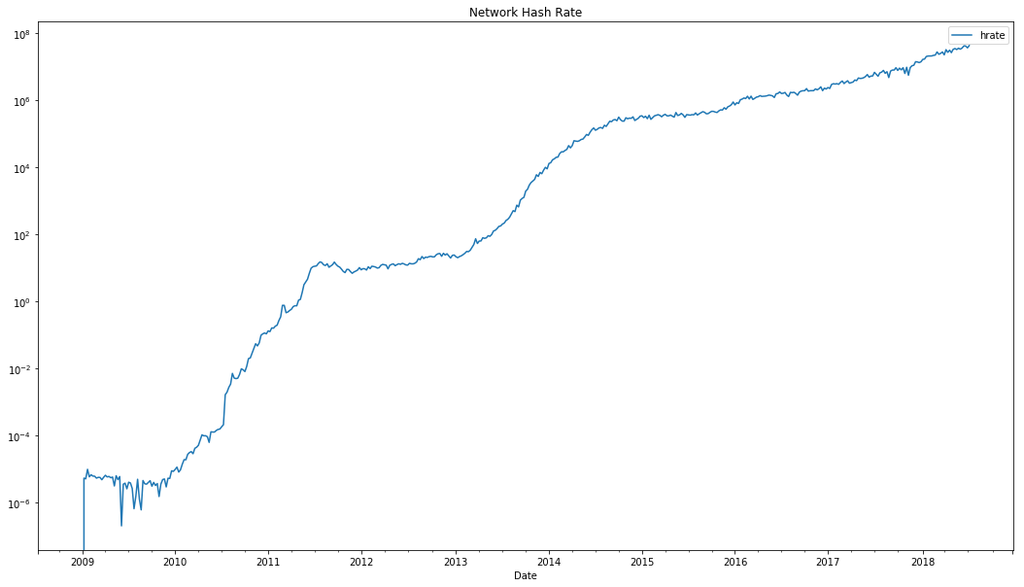

```python
# Bitcoin Hash Rate
# The estimated number of giga hashes per second
# (billions of hashes per second) the bitcoin network is performing.
hrate = ql.get("BCHAIN/HRATE", collapse="weekly")
# hrate = hrate.rename(columns={"Value": "Network Hash Rate"})
hrate = hrate.rename(columns={"Value": "hrate"})

hrate.plot(title='Network Hash Rate', figsize=(18,10), logy=True)
```

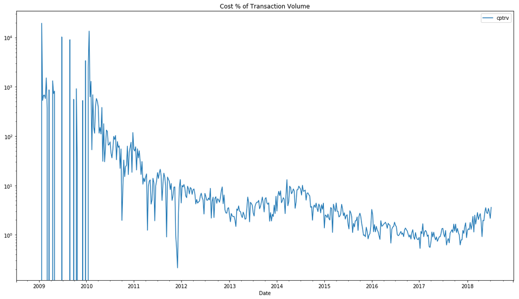

```python
# Bitcoin Cost % of Transaction Volume
# Data showing miners revenue as as percentage of the transaction volume.
cptrv = ql.get("BCHAIN/CPTRV", collapse="weekly")
# cptrv = cptrv.rename(columns={"Value": "Cost % of Transaction Volume"})
cptrv = cptrv.rename(columns={"Value": "cptrv"})

cptrv.plot(title='Cost % of Transaction Volume', figsize=(18,10), logy=True)
```

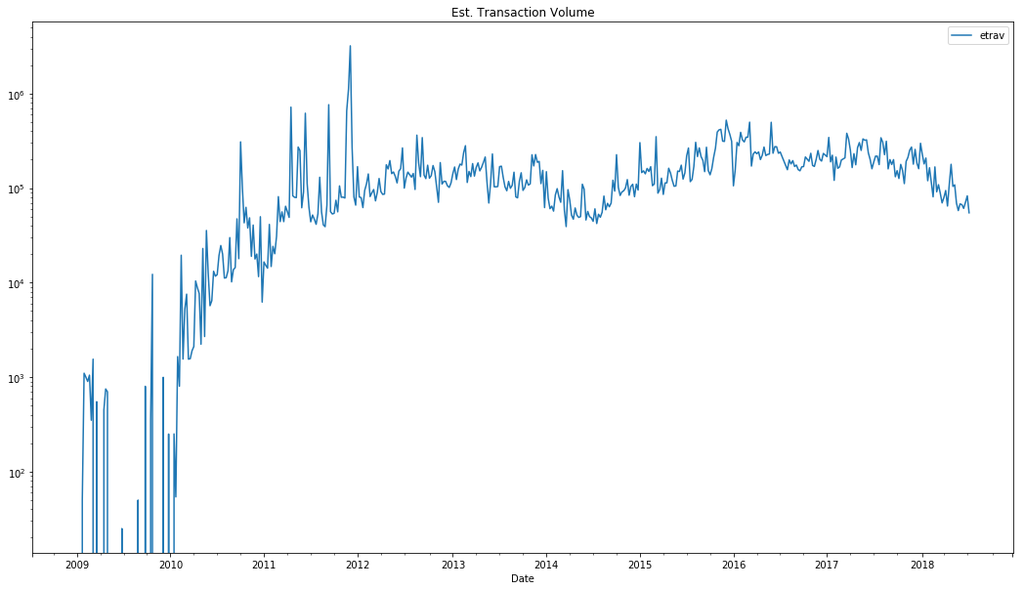

```python
# Bitcoin Estimated Transaction Volume
# Similar to the total output volume with the addition of an algorithm
# which attempts to remove change from the total value. This may be a more
# accurate reflection of the true transaction volume.
etrav = ql.get("BCHAIN/ETRAV", collapse="weekly")
# etrav = etrav.rename(columns={"Value": "Est. Transaction Volume"})
etrav = etrav.rename(columns={"Value": "etrav"})

etrav.plot(title='Est. Transaction Volume', figsize=(18,10), logy=True)
```

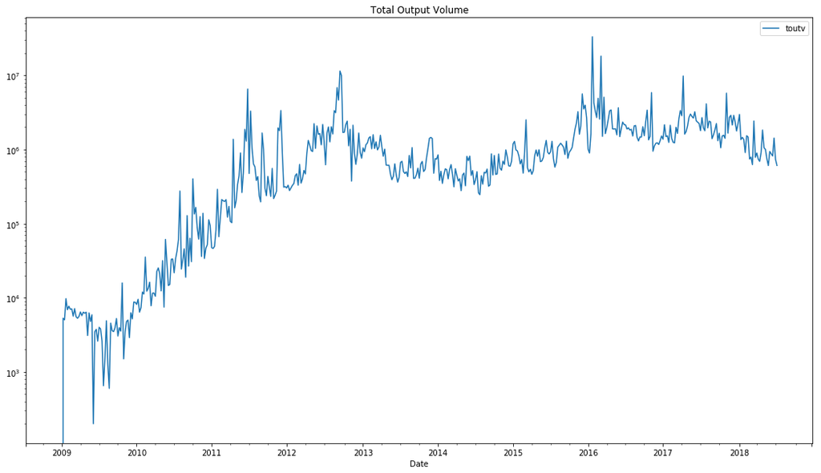

```python
# Bitcoin Total Output Volume
# The total value of all transaction outputs per day. This includes coins
# which were returned to the sender as change.
toutv = ql.get("BCHAIN/TOUTV", collapse="weekly")
# toutv = toutv.rename(columns={"Value": "Total Output Volume"})
toutv = toutv.rename(columns={"Value": "toutv"})

toutv.plot(title='Total Output Volume', figsize=(18,10), logy=True)
```

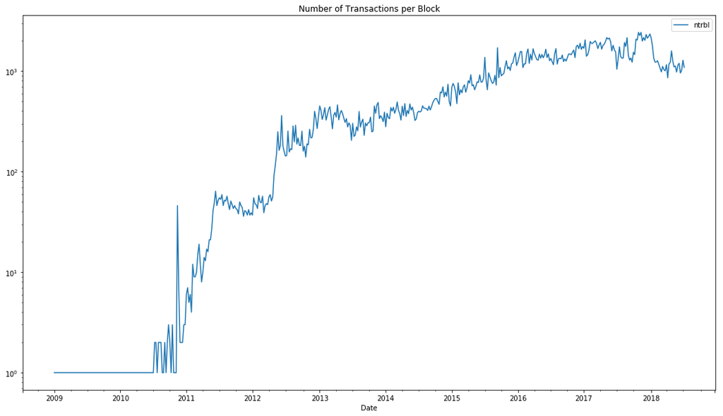

```python
# Bitcoin Number of Transactions per Block
# The average number of transactions per block.
ntrbl = ql.get("BCHAIN/NTRBL", collapse="weekly")
# ntrbl = ntrbl.rename(columns={"Value": "Number of Transactions per Block"})
ntrbl = ntrbl.rename(columns={"Value": "ntrbl"})

ntrbl.plot(title='Number of Transactions per Block', figsize=(18,10), logy=True)
```

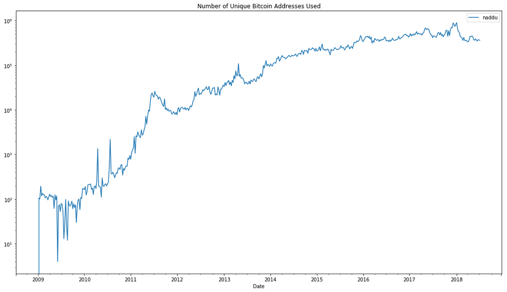

```python
# Bitcoin Number of Unique Bitcoin Addresses Used
# Number of unique bitcoin addresses used per day.
naddu = ql.get("BCHAIN/NADDU", collapse="weekly")
# naddu = naddu.rename(columns={"Value": "Number of Unique Bitcoin Addresses Used"})
naddu = naddu.rename(columns={"Value": "naddu"})

naddu.plot(title='Number of Unique Bitcoin Addresses Used', figsize=(18,10), logy=True)
```

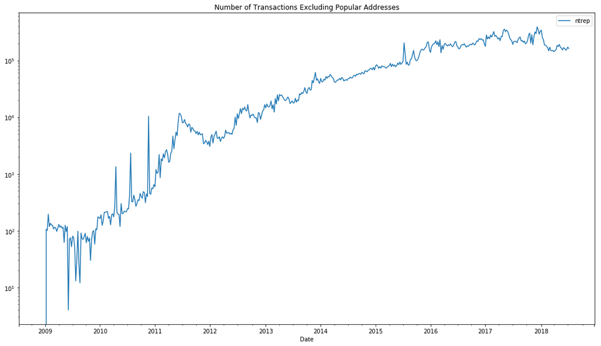

```python
# Bitcoin Number of Transactions Excluding Popular Addresses
# Data showing the total number of unique bitcoin transactions per day excluding those
# which involve any of the top 100 most popular addresses popular addresses.
ntrep = ql.get("BCHAIN/NTREP", collapse="weekly")
# ntrep = ntrep.rename(columns={"Value": "Number of Transactions Excluding Popular Addresses"})
ntrep = ntrep.rename(columns={"Value": "ntrep"})

ntrep.plot(title='Number of Transactions Excluding Popular Addresses', figsize=(18,10), logy=True)
```

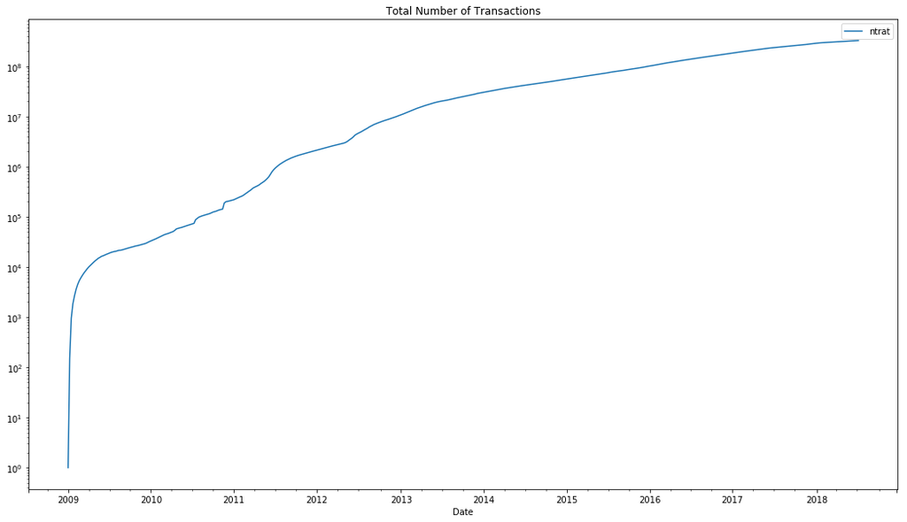

```python
# Bitcoin Total Number of Transactions
# Total number of unique bitcoin transactions per day.
ntrat = ql.get("BCHAIN/NTRAT", collapse="weekly")
# ntrat = ntrat.rename(columns={"Value": "Total Number of Transactions"})
ntrat = ntrat.rename(columns={"Value": "ntrat"})

ntrat.plot(title='Total Number of Transactions', figsize=(18,10), logy=True)
```

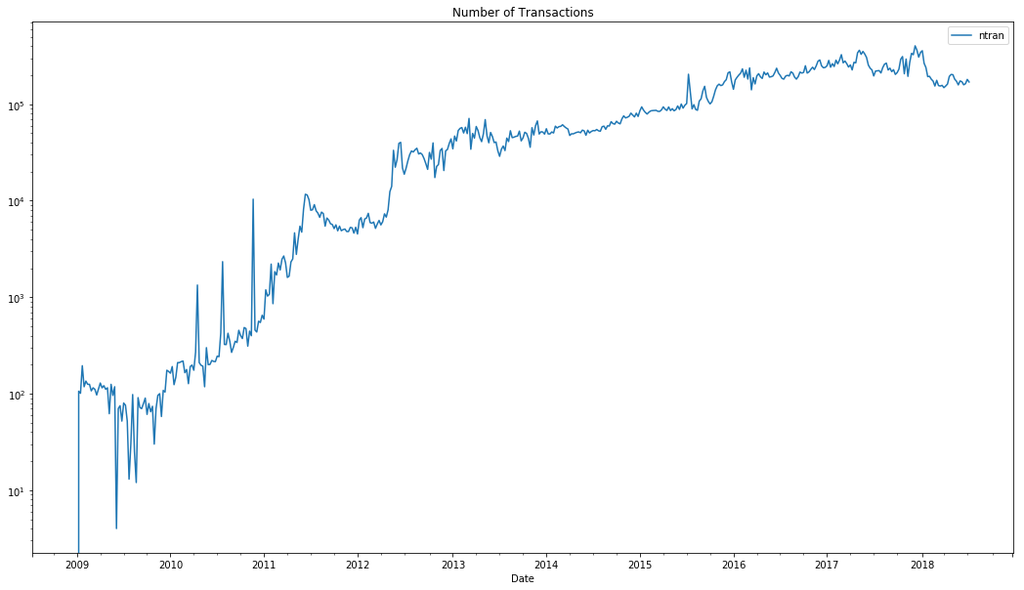

```python
# Bitcoin Number of Transactions
# Total number of unique bitcoin transactions per day.
ntran = ql.get("BCHAIN/NTRAN", collapse="weekly")
# ntran = ntran.rename(columns={"Value": "Number of Transactions"})
ntran = ntran.rename(columns={"Value": "ntran"})

ntran.plot(title='Number of Transactions', figsize=(18,10), logy=True)
```

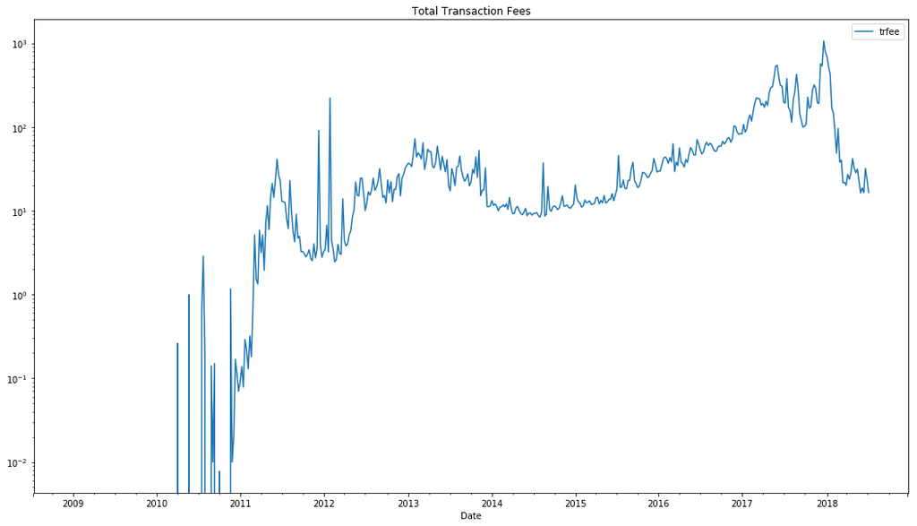

```python
# Bitcoin Total Transaction Fees
# Data showing the total BTC value of transaction fees miners earn per day.
trfee = ql.get("BCHAIN/TRFEE", collapse="weekly")
# trfee = trfee.rename(columns={"Value": "Total Transaction Fees"})
trfee = trfee.rename(columns={"Value": "trfee"})

trfee.plot(title='Total Transaction Fees', figsize=(18,10), logy=True)
```

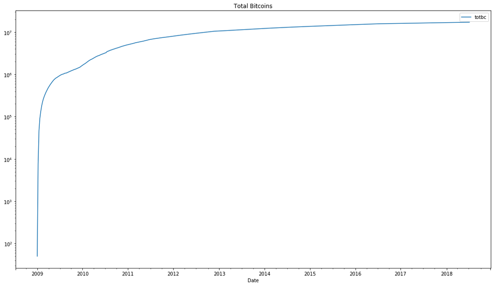

```python
# Total Bitcoins
# Data showing the historical total number of bitcoins which have been mined.
totbc = ql.get("BCHAIN/TOTBC", collapse="weekly")
# totbc = totbc.rename(columns={"Value": "Total Bitcoins"})
totbc = totbc.rename(columns={"Value": "totbc"})

totbc.plot(title='Total Bitcoins', figsize=(18,10), logy=True)
```

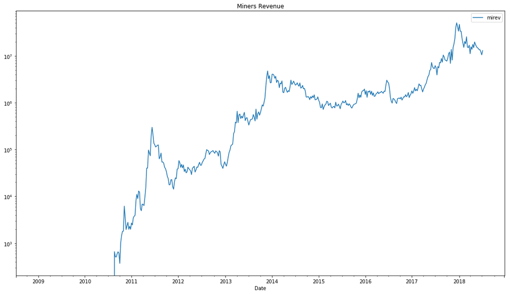

```python
# Bitcoin Miners Revenue
# Historical data showing:
# (number of bitcoins mined per day + transaction fees) * market price.
mirev = ql.get("BCHAIN/MIREV", collapse="weekly")
# mirev = mirev.rename(columns={"Value": "Miners Revenue"})
mirev = mirev.rename(columns={"Value": "mirev"})

mirev.plot(title='Miners Revenue', figsize=(18,10), logy=True)
```

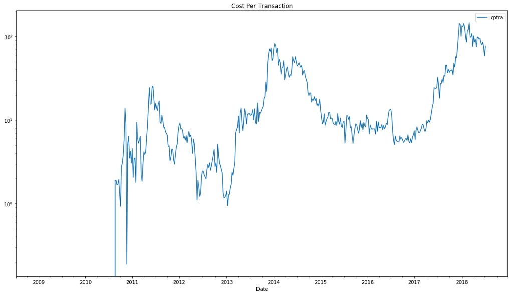

```python
# Bitcoin Cost Per Transaction
# Data showing miners revenue divided by the number of transactions.
cptra = ql.get("BCHAIN/CPTRA", collapse="weekly")
# cptra = cptra.rename(columns={"Value": "Cost Per Transaction"})
cptra = cptra.rename(columns={"Value": "cptra"})

cptra.plot(title='Cost Per Transaction', figsize=(18,10), logy=True)
```

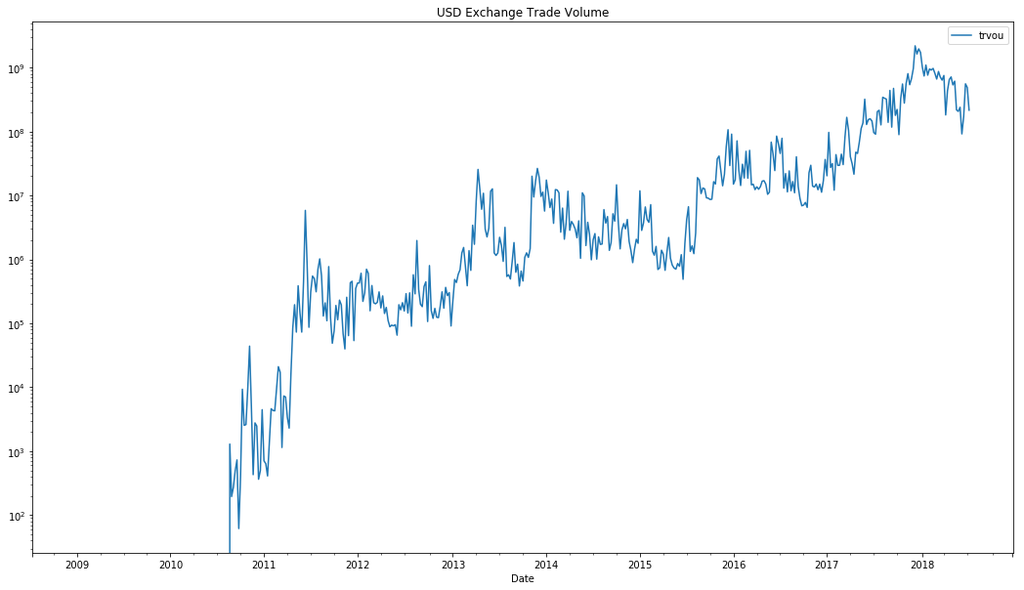

```python
# Bitcoin USD Exchange Trade Volume
# Data showing the USD trade volume from the top exchanges.
trvou = ql.get("BCHAIN/TRVOU", collapse="weekly")
# trvou = trvou.rename(columns={"Value": "USD Exchange Trade Volume"})
trvou = trvou.rename(columns={"Value": "trvou"})

trvou.plot(title='USD Exchange Trade Volume', figsize=(18,10), logy=True)
```

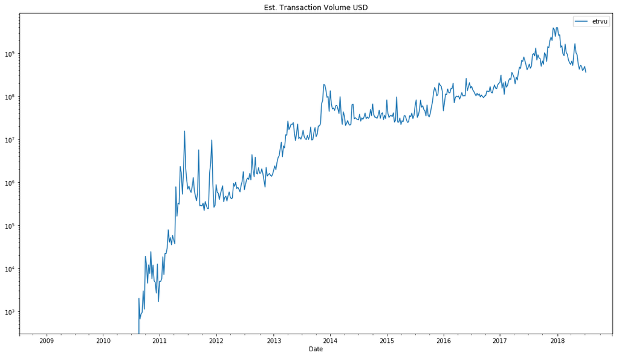

```python
# Bitcoin Estimated Transaction Volume USD
# Similar to the total output volume with the addition of an algorithm
# which attempts to remove change from the total value. This may be a
# more accurate reflection of the true transaction volume.
etrvu = ql.get("BCHAIN/ETRVU", collapse="weekly")
# etrvu = etrvu.rename(columns={"Value": "Est. Transaction Volume USD"})
etrvu = etrvu.rename(columns={"Value": "etrvu"})

etrvu.plot(title='Est. Transaction Volume USD', figsize=(18,10), logy=True)
```

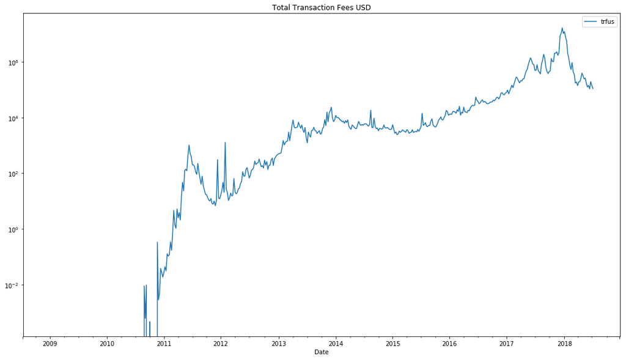

```python
# Bitcoin Total Transaction Fees USD
# Data showing the total BTC value of transaction fees miners earn per day in USD.
trfus = ql.get("BCHAIN/TRFUS", collapse="weekly")
# trfus = trfus.rename(columns={"Value": "Total Transaction Fees USD"})
trfus = trfus.rename(columns={"Value": "trfus"})

trfus.plot(title='Total Transaction Fees USD', figsize=(18,10), logy=True)
```

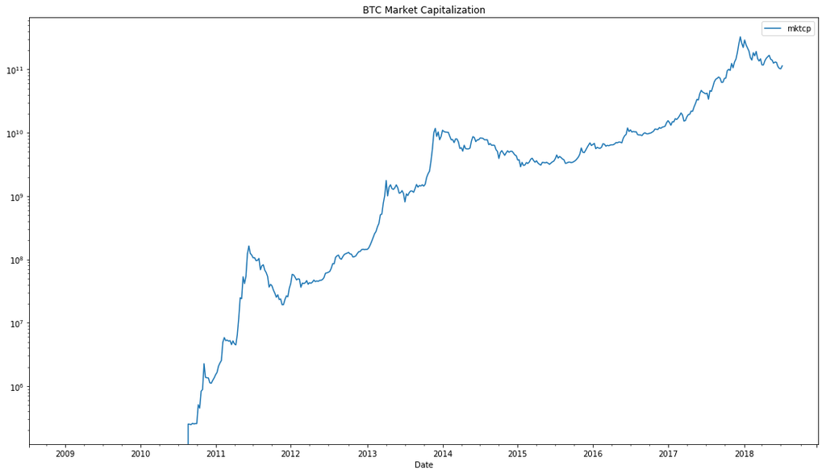

```python
# Bitcoin Market Capitalization
# Data showing the total number of bitcoins in circulation at the market price in USD.
mktcp = ql.get("BCHAIN/MKTCP", collapse="weekly")
# mktcp = mktcp.rename(columns={"Value": "Market Capitalization"})
mktcp = mktcp.rename(columns={"Value": "mktcp"})

mktcp.plot(title='BTC Market Capitalization', figsize=(18,10), logy=True)
```

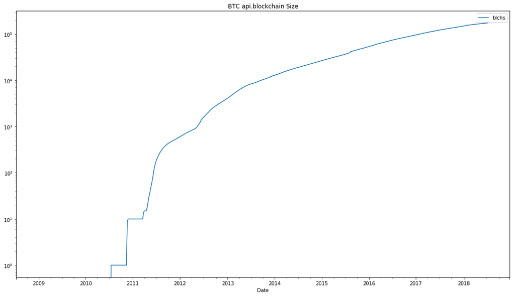

```python
# Bitcoin api.blockchain Size
# The total size of all block headers and transactions.
# Not including database indexes.
blchs = ql.get("BCHAIN/BLCHS", collapse="weekly")
# blchs = blchs.rename(columns={"Value": "api.blockchain Size"})
blchs = blchs.rename(columns={"Value": "blchs"})

blchs.plot(title='BTC api.blockchain Size', figsize=(18,10), logy=True)
```

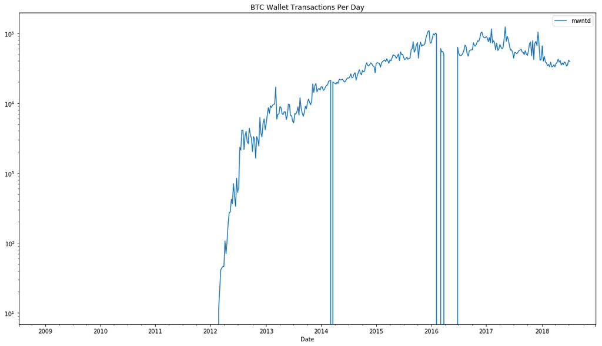

```python
# Bitcoin My Wallet Number of Transaction Per Day
# Number of transactions made by MyWallet Users per day.
mwntd = ql.get("BCHAIN/MWNTD", collapse="weekly")
# mwntd = mwntd.rename(columns={"Value": "BTC Wallet Transactions Per Day"})
mwntd = mwntd.rename(columns={"Value": "mwntd"})

mwntd.plot(title='BTC Wallet Transactions Per Day', figsize=(18,10), logy=True)
```

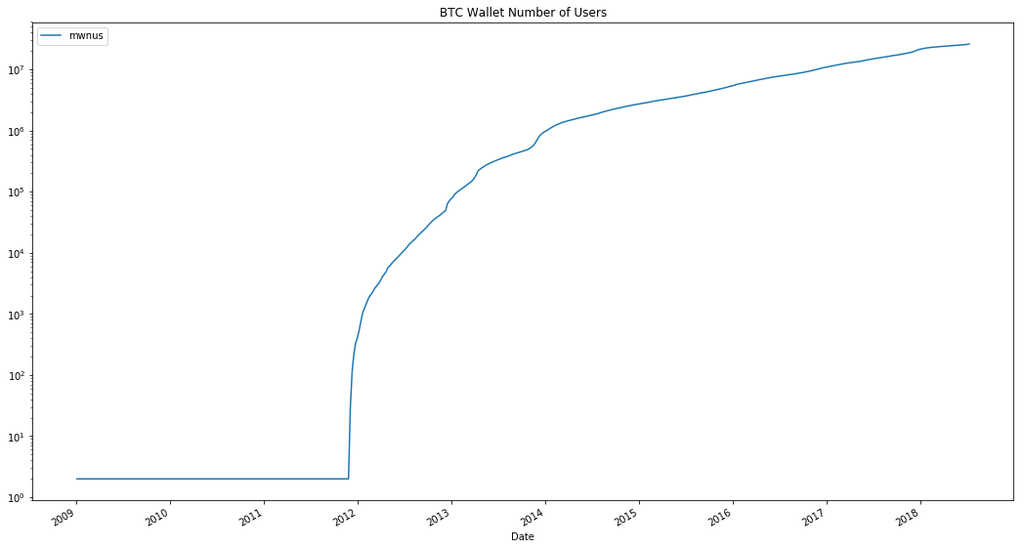

```python
# Bitcoin My Wallet Number of Users
# Number of wallets hosts using our MyWallet Service.
mwnus = ql.get("BCHAIN/MWNUS", collapse="weekly")
# mwnus = mwnus.rename(columns={"Value": "BTC Wallet Number of Users"})
mwnus = mwnus.rename(columns={"Value": "mwnus"})

mwnus.plot(title='BTC Wallet Number of Users', figsize=(18,10), logy=True)
```

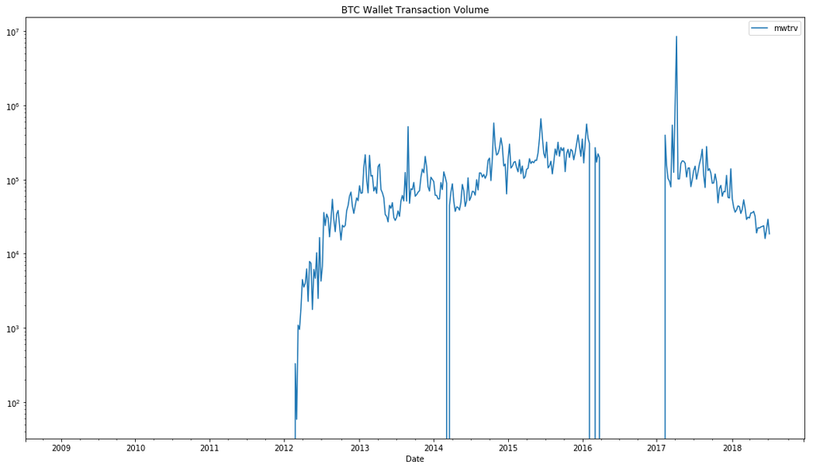

```python
# Bitcoin My Wallet Transaction Volume
# 24hr Transaction Volume of our MyWallet service.
mwtrv = ql.get("BCHAIN/MWTRV", collapse="weekly")
# mwtrv = mwtrv.rename(columns={"Value": "BTC Wallet Transaction Volume"})
mwtrv = mwtrv.rename(columns={"Value": "mwtrv"})

mwtrv.plot(title='BTC Wallet Transaction Volume', figsize=(18,10), logy=True)
```

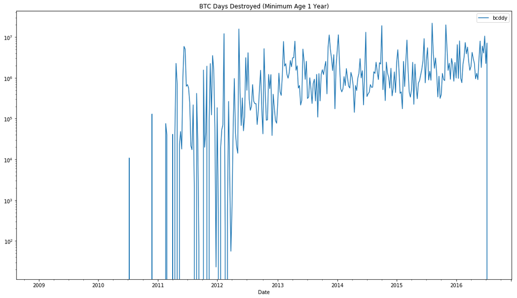

```python
# Data Currently Not Used
#############################################
# Bitcoin Days Destroyed (Minimum Age 1 Year)
bcddy = ql.get("BCHAIN/BCDDY", collapse="weekly")
# bcddy = bcddy.rename(columns={"Value": "Days Destroyed (Minimum Age 1 Year)"})
bcddy = bcddy.rename(columns={"Value": "bcddy"})

bcddy.plot(title='BTC Days Destroyed (Minimum Age 1 Year)', figsize=(18,10), logy=True)
```

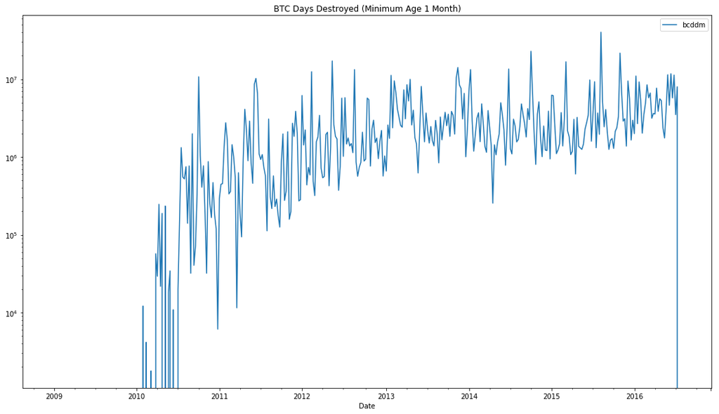

```python
# Bitcoin Days Destroyed (Minimum Age 1 Month)
bcddm = ql.get("BCHAIN/BCDDM", collapse="weekly")
# bcddm = bcddm.rename(columns={"Value": "Days Destroyed (Minimum Age 1 Month)"})
bcddm = bcddm.rename(columns={"Value": "bcddm"})

bcddm.plot(title='BTC Days Destroyed (Minimum Age 1 Month)', figsize=(18,10), logy=True)
```

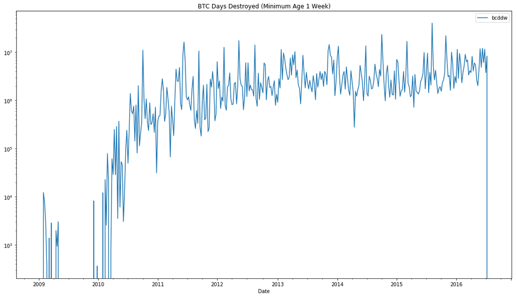

```python
# Bitcoin Days Destroyed (Minimum Age 1 Week)
bcddw = ql.get("BCHAIN/BCDDW", collapse="weekly")
# bcddw = bcddw.rename(columns={"Value": "Days Destroyed (Minimum Age 1 Week)"})
bcddw = bcddw.rename(columns={"Value": "bcddw"})

bcddw.plot(title='BTC Days Destroyed (Minimum Age 1 Week)', figsize=(18,10), logy=True)
```

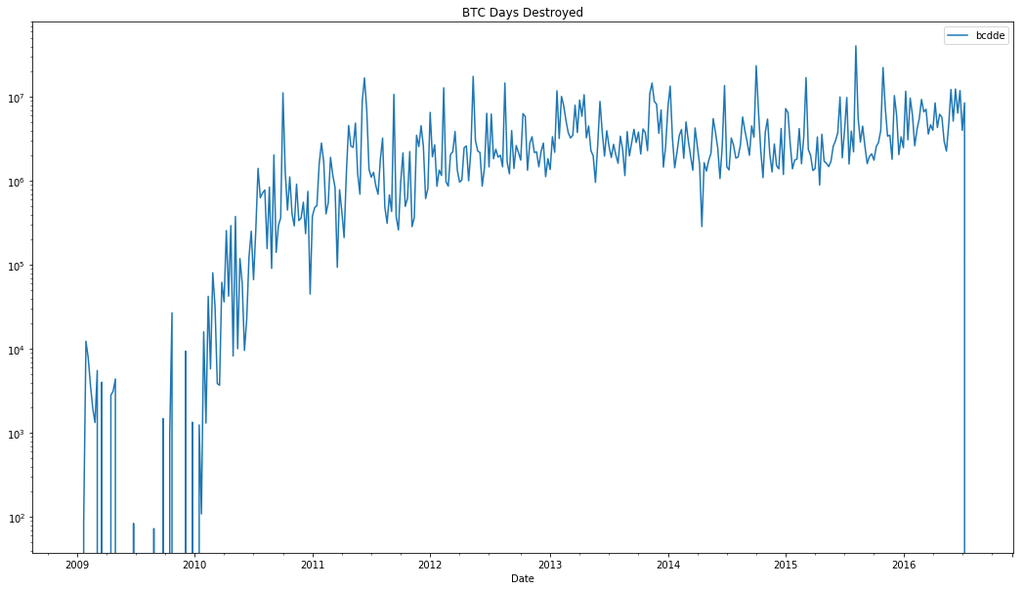

```python
# Bitcoin Days Destroyed
bcdde = ql.get("BCHAIN/BCDDE", collapse="weekly")
# bcdde = bcdde.rename(columns={"Value": "Days Destroyed"})
bcdde = bcdde.rename(columns={"Value": "bcdde"})

bcdde.plot(title='BTC Days Destroyed', figsize=(18,10), logy=True)
```